# PowerPuff Genes Project

2025-03-17

## Getting Started

### Librarires prerequisites

- IRanges
- dplyr
- tidyverse
- …

### Data files

- salmon counts
- salmon tpm
- maybe more files, maybe not

## RNA-seq differential expression analysis

### Define variables

```r
COUNTS_PATH      <- "data/NF3-14_rep1/salmon.merged.gene_counts.tsv"
TPM_PATH         <- "data/NF3-14_rep1/salmon.merged.gene_tpm.tsv"
FILTER_TRESHOLD  <- 5
P_VALUE_FILTER   <- 0.01
LOG2_FOLD_FILTER <- 2
```

- Maybe before moving to counts_filtered and further proccesing check if the data makes sense. For instance:
  - Is dox regulating any genes (such as GFP or other reporter) that we can verify the increased expression (higher counts) for later time points? Verify this is the case in the counts_orig df.
  - For the previous question, we could even consider making a simple ggplot showing the expression of the reporter for all time points. May be also easier to do for the tpm files.
- For the filtering, look more into what other people do or try different parameters
  - I have seen filtering by rowSums(counts_matrix) > 10
  - Also, I have seen filtering done at the dds (DESeqDataSetFromMatrix) object instead of filtering before. Maybe see what is the difference?

### Counts analysis

```r
# Read raw count data and make dictionary mapping gene id with gene name
counts_orig  <- read.table(COUNTS_PATH, header=TRUE, row.names=1)
g2s          <- data.frame(gene_id = rownames(counts_orig),
                           gene_name = counts_orig[ , 1])
write.csv(g2s, "results/g2s.csv")

# Remove gene name column from counts and convert counts to numerical rounded matrix
counts           <- counts_orig %>% select(-gene_name)
counts_matrix    <- as.matrix(counts)
counts_matrix    <- round(counts_matrix)

# Filter genes with no counts for any of the samples
counts_filtered  <- counts_matrix[rowSums(counts_matrix) > FILTER_TRESHOLD, ]

save(counts_orig, counts, counts_filtered, g2s, file = "results/counts_files.RData")
```

```r
# Make a column from the titles of the columns of the counts_matrix table
deseq_samples  <- data.frame(sample_id = colnames(counts))

# Get the time and replicate values from the sample names in deseq_samples
split_values     <- strsplit(deseq_samples$sample_id, "_")
time_values      <- sapply(split_values, function(x) x[[2]])
replicate_values <- sapply(split_values, function(x) x[[3]])

# Add time and replicate values as columns to deseq_samples and factor them
deseq_samples$time_point <- time_values
deseq_samples$replicate  <- replicate_values
deseq_samples$time_point <- factor(deseq_samples$time_point)
deseq_samples$replicate  <- factor(deseq_samples$replicate)

# Testing whether sample sheet and counts are arranged properly
stopifnot(all(colnames(counts) == rownames(deseq_samples$sample_id)))

save(deseq_samples, file = "results/deseq_samples.RData")
```

```r
# Prepare DESeq dataset
dds <- DESeqDataSetFromMatrix(countData = counts_filtered,
                              colData = deseq_samples,
                              design = ~ time_point)

# Run DESeq and get the names for the comparisons
dds            <- DESeq(dds)
results_names  <- resultsNames(dds)
results_names  <- results_names[results_names != "Intercept"]

# Regularized Log transformation (rlog) stabilizes variance for downstream visualization or clustering. (not sure if need to include)
#rlog_counts <- rlog(dds, blind = TRUE)
#rlog_counts_matrix <- assay(rlog_counts)
#write_rds(rlog_counts_matrix, "results/rlog_counts.rds")

save(dds, file = "results/dds.RData")
```

```r
# Create empty df to store results values
results <- data.frame("gene_id" = character(),
                      "baseMean" = numeric(),
                      "log2FoldChange" = numeric(),
                      "lfcSE" = numeric(),
                      "stat" = numeric(),
                      "pvalue" = numeric(),
                      "padj" = numeric(),
                      "gene_name" = character(),
                      "result_name" = character())

# Loop to get the results of each comparison from dds object and make main res_df with all of them
for(i in 1:length(results_names)) {
  results_name <- results_names[i] # get time comparison i
  res <- results(dds, name = results_name) # get DESeq results for time comparison i
  # Temporary df to store the results for each comparison i
  tmp_res_df <- res %>% as.data.frame() %>%
    rownames_to_column("gene_id") %>% merge(g2s) %>% mutate(result_name = results_name)
  # Add the temporary df to the main res_df for each comparison i
  results <- bind_rows(results, tmp_res_df)
}
```

```r
# Filter based on p-value < 0.05 and log2 fold change > 1
filtered_results <- results %>%
  filter(padj < P_VALUE_FILTER, abs(log2FoldChange) > LOG2_FOLD_FILTER)

# Get all gene names that are significant (drop gene name repetitions)
filtered_genes <- as.data.frame(filtered_results$gene_name, collapse = "\n")
filtered_genes <- unique(filtered_genes)
colnames(filtered_genes)[1] <- "gene_name"

# Now let's write this out and do gene enrichment analysis
write.table(filtered_genes["gene_name"], row.names = FALSE, col.names = FALSE, "results/filtered_genes.csv")

save(results, filtered_results, filtered_genes, file = "results/DESeq2_results.RData")

# May wanna take a look at these genes. Start at: https://maayanlab.cloud/Enrichr/
```

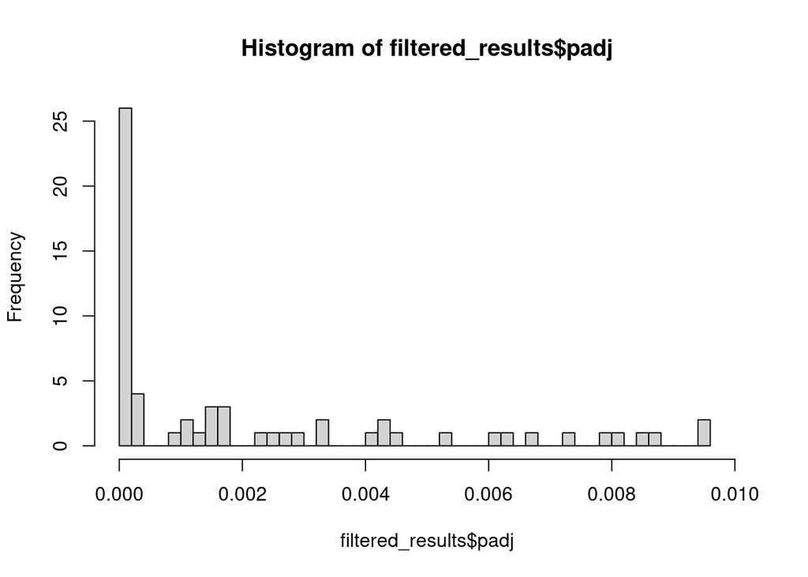

```r
# Distribution of baseMean, lfcSE, p-values and fold change
#hist(filtered_results$baseMean, xlim = c(0, 10000), breaks = 500) # May remove this plot
#hist(filtered_results$lfcSE, xlim = c(0,5), breaks = 100) # May remove this histogram as well
hist(filtered_results$padj, xlim = c(0,P_VALUE_FILTER ), breaks = 50)
```

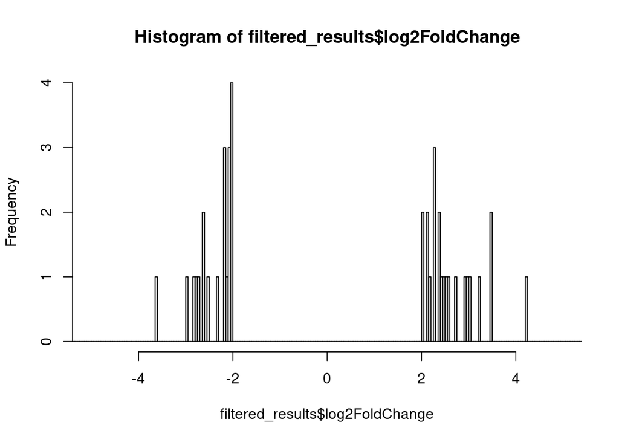

```r
hist(filtered_results$log2FoldChange, xlim = c(-5, 5), breaks = 1000)
```

```r
# T-test comparing baseMean expression of all genes vs filtered genes
basemean_all_genes <- median(results$baseMean)
basemean_fil_genes <- median(filtered_results$baseMean)
t.test(results$baseMean, filtered_results$baseMean)
```

```
##
##  Welch Two Sample t-test
##
## data:  results$baseMean and filtered_results$baseMean
## t = 6.8085, df = 62.289, p-value = 4.516e-09
## alternative hypothesis: true difference in means is not equal to 0
## 95 percent confidence interval:
##   619.843 1135.019
## sample estimates:
## mean of x mean of y
## 1092.5958  215.1649
```

```r
# Intersect by gene_name filtered results table and raw counts
counts_filtered_genes <- counts_orig[filtered_results$gene_id,]
# TODO delete repetitive instances of genes
```

### TPM Analysis

```r
# Read raw tpm data and delete gene name column
tpm_orig  <- read.table(TPM_PATH, header=TRUE, row.names=1)
tpm       <- tpm_orig %>% select(-gene_name)

# Filter genes with no counts for any of the samples
tpm_filtered <- tpm[rowSums(tpm) > FILTER_TRESHOLD, ]
```

```r
# Loop to calculate avg and sd for replicates at a given time point
time_points <- c("0", "12", "24", "48", "96")
avg_and_sd_values <- list()
for (tp in time_points) {
  cols <- grep(paste0("WT_", tp, "_"), colnames(tpm_filtered))
  avg  <- rowMeans(tpm_filtered[, cols])
  sd   <- apply(tpm_filtered[, cols], 1, sd)
  sd   <- data.frame(sd)
  combined <- cbind(avg, sd)
  avg_and_sd_values <- c(avg_and_sd_values, list(combined))
}

# Convert the list to a data frame and add column names for the respective timepoint
avg_and_sd_values <- do.call(cbind,  avg_and_sd_values)
colnames(avg_and_sd_values) <- paste0(rep(time_points, each = 2), c("_avg", "_sd"))

save(tpm_orig, tpm_filtered, avg_and_sd_values, file = "results/tpm_results.RData" )
```

### Image analysis

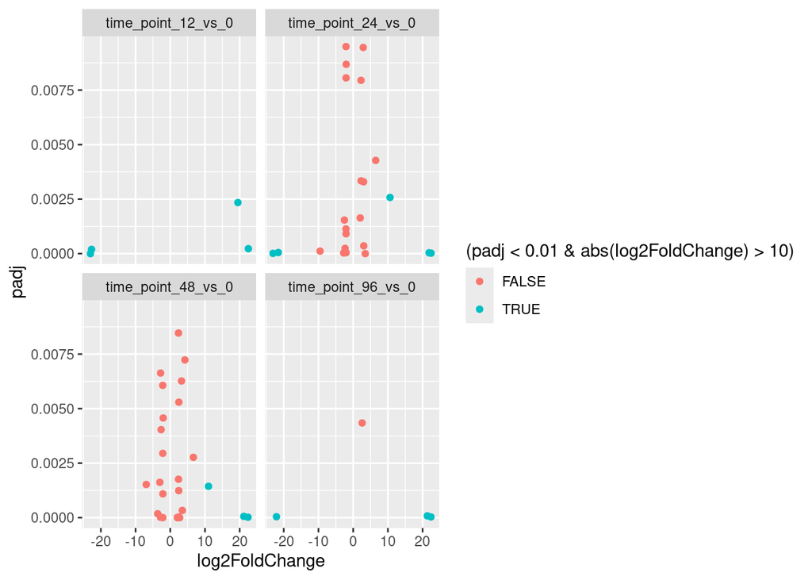

```r
# Delete enviroment and load counts and tpm data
load("results/DESeq2_results.RData")
load("results/tpm_results.RData")

# Volcano plot for log fold change vs padj. TRUE color may be genes worth looking into.
ggplot(filtered_results, aes(x = log2FoldChange, y = padj, color = (padj<0.01 & abs(log2FoldChange) > 10 ))) +
  facet_wrap(result_name ~ .) +
  geom_point()
```

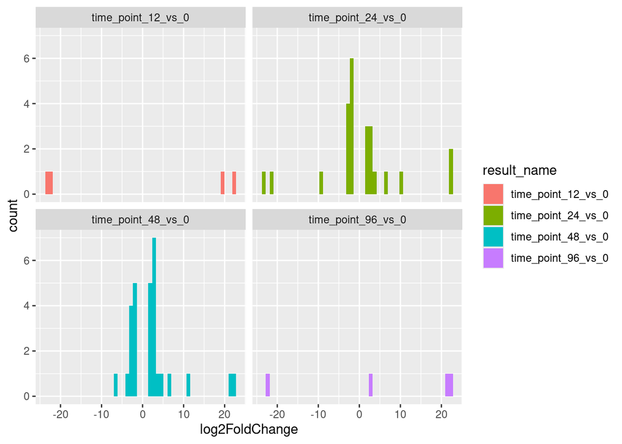

```r
# Histogram for log fold change vs padj
ggplot(filtered_results, aes(x = log2FoldChange, fill = result_name)) +
  facet_wrap(result_name ~ .) +
  geom_histogram(bins = 50)
```

## IGV Results

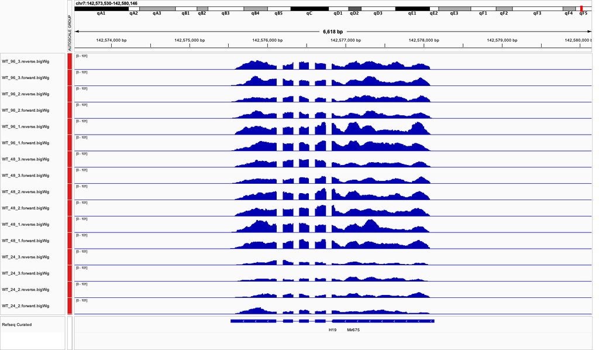

This are the timepoint tracks for gene H19 using the GRCm38/mm10 genome

## Future directions

Pretty cool video on DESeq2 analysis: https://www.youtube.com/watch?v=NGbZmlGLG5w&t=264s

Ideas of plots to include: - Circos plot - Needs to know where the gene is located so need to use biomaRt to get data from ensembl and get the gene information (it looks a bit complicated) - Will need to save a csv file with Gene ID, chromosome name, start position, end position + rows in results from DESeq2 - Plots can be made in Circa (easier) or through bash (harder)